# A3: SPL Library Checkouts

Oscar Maldonado

02/21/2023

### Introduction

The data for this assignment comes from the Seattle Public Library. I am using smaller data sets based on the initial 40 million entries to create a report about library circulation trends.

### Summary Information

- What is the average number of checkouts for each item?

Average Checkouts for each Matieral in the Seattle Public Libray

| Material Checked out | Average Checkouts |
| --- | --- |
| MIXED | 440.40856 |
| MAGAZINE | 61.23701 |
| ER | 28.44944 |
| AUDIOBOOK | 25.25704 |
| EBOOK | 25.13426 |
| VIDEODISC | 24.43032 |
| CR | 23.73762 |
| REGPRINT | 23.19126 |
| MUSIC | 21.80855 |
| BOOK | 20.92514 |
| SONG | 20.28797 |
| ER, SOUNDDISC | 18.51351 |
| MOVIE | 18.28628 |
| SOUNDDISC, VIDEODISC | 16.93151 |
| COMIC | 15.77851 |
| SOUNDDISC | 15.73852 |
| LARGEPRINT | 15.65094 |
| ER, VIDEODISC | 15.32258 |
| SOUNDREC | 14.13866 |
| VIDEOREC | 13.87500 |
| VISUAL | 13.70833 |
| TELEVISION | 13.67265 |
| VIDEOCASS | 13.23529 |
| UNSPECIFIED | 12.89474 |
| VIDEOCART | 11.57143 |
| ER, SOUNDDISC, SOUNDREC | 11.00000 |
| ATLAS | 10.91667 |
| ER, SOUNDREC | 10.73913 |
| GLOBE | 10.00000 |
| MAP | 10.00000 |
| SOUNDCASS | 10.00000 |
| VIDEOCASS, VIDEODISC | 10.00000 |

- What is the month or year with the most/least checkouts for a book that you’re interested in?
  - The year for the most checkouts for the book The Lightning Thief: Percy Jackson and the Olympians Series, Book 1 was 2020 with 20 checkouts that year.
- What is the month or year with the most/least checkouts for ebooks?
  - the full year for the least amount of ebook checkouts was 2017 with 18371 checkouts.
- How has the number of print book checkouts changed over time?
  - The number for book checkouts has fluctuated throughout the years, in 2017 total book checkouts were 73048 and as of 2022 (last full year) books had 41747 checkouts.
- How did the Pandemic affect the Seattle Public Library?
  - During the Pandemic a lot of in person shopping/visitation was no longer a viable option, and this is reflected in the data. The amount of physical checkouts for the Seattle Public Library (SPL) in 2019 was 102601 checkouts, in 2020 this number plummeted to 24838 total checkouts, and we see the number of digital checkouts increase from 53174 in 2019 to 68555 in 2020. We also see the checkouts for digital media begin to increase and checkouts for physical books around this time period, the checkouts for physical books in 2017 was 73048 checkouts, while in 2022 (last full year) this figure fell to 41747 checkouts. On the other hand, checkouts for medias such as ebooks and audiobooks increased from 18371 checkouts and 10486 checkouts in 2017 to 40164 checkouts and 36871 checkouts in 2022.

### The Dataset

- Who collected/published the data?
  - The Seattle Public Library
- What are the parameters of the data (dates, number of checkouts, kinds of books, etc.)?
  - “UsageClass” “CheckoutType” “MaterialType” “CheckoutYear” “CheckoutMonth” “Checkouts” “Title”  
    “ISBN” “Creator” “Subjects” “Publisher” “PublicationYear”
- How was the data collected or generated?
  - electronically through the library’s integrated library system
- Why was the data collected?
  - to help the library manage its collection, track usage, and make informed decisions about resource allocation and collection development.
- What, if any, ethical questions do you need to consider when working with this data?
  - Privacy of the users and data accuracy are some concerns
- What are possible limitations or problems with this data? (at least 200 words)
  - This data has a limited scope, it only includes records from the Seattle Public Library and it may not be an accurate reflection of checkout trends in the libraries of other areas. Missing or incomplete data is also an issue, these missing values could skew any projects or inferences to be made about this data. The COVID-19 pandemic pandemic likely had a significant impact on library usage and checkout trends and the data may not accurately reflect these changes or account for the potential disruptions to library services.

### First Trends Over Time Chart

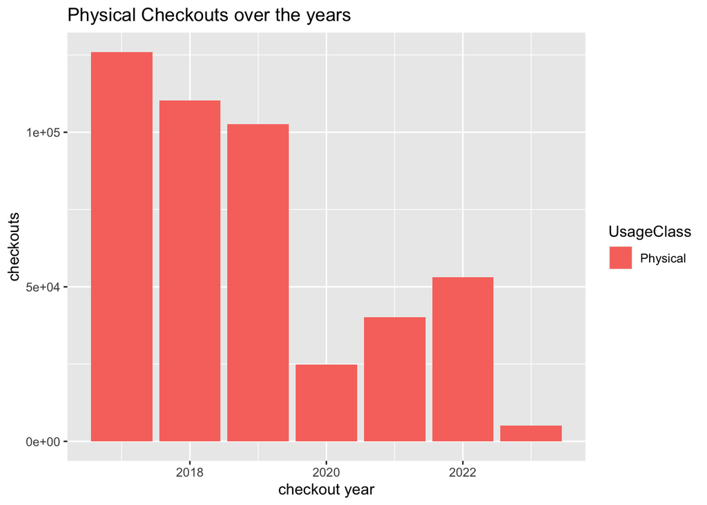

In this bar chart we can see the amount of physical checkouts made at the Seattle Public Library every year, spanning the years of 2017 to 2023. We can see the amount of physical checkouts gradually decreasing, but in 2020, physical checkouts took a sharp decline largely in part due to the COVID-19 pandemic. We see the amount of physical checkouts slightly pickup again in the years to come following the effects of the pandemic but they never truly recover their glory.

### Second Trends Over Time Chart

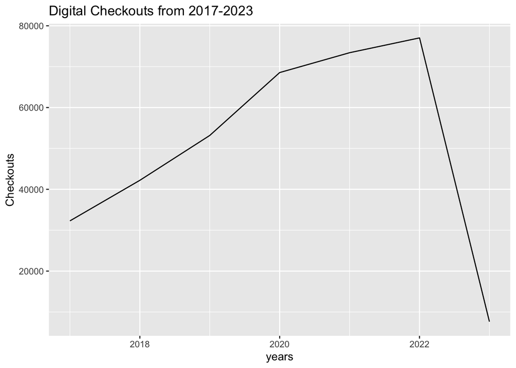

In this line chart we can see the amount of digital checkouts made at the Seattle Public Library every year, spanning the years of 2017 to 2023. We can see the amount of digital checkouts increase at a decent rate, but in 2020 and the years to come, digital checkouts increased largely in part due to the COVID-19 pandemic. This trend is something I expect to continue on through the decade as we advance as a more technologically reliant society and books become obsolete.

### Third Trends Over Time Chart

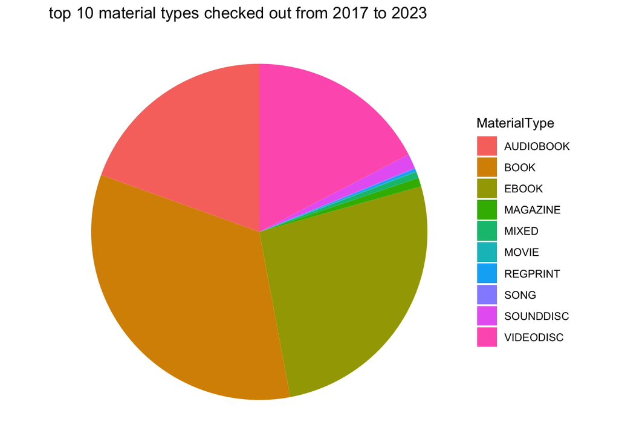